# Exercise 1: Hospital Stay

```python
# %matplotlib notebook
import pandas as pd
import warnings
import matplotlib.pyplot as plt
import seaborn as sns

from IPython.display import display
from typing import List
```

```python
warnings.filterwarnings(action="ignore")
plt.rcParams["figure.figsize"] = 18, 8
pd.set_option('float_format', "{:,.2f}".format)
```

## Preliminary steps

In the next bit, we load the data, generate a training and an evaluation set.

### Load the data and check missing data and type inconsistencies

```python
data = pd.read_csv("hospital_stay_data.csv")

summary = pd.DataFrame().assign(
    mode=data.mode(0).loc[0],
    dtype=data.dtypes,
    missing=data.isna().sum(0),
    unique=data.nunique()
)

display(summary)
```

|  | mode | dtype | missing | unique |
| --- | --- | --- | --- | --- |
| case_id | 1 | int64 | 0 | 318438 |
| Hospital_code | 26.00 | int64 | 0 | 32 |
| Hospital_type_code | a | object | 0 | 7 |
| City_Code_Hospital | 1.00 | int64 | 0 | 11 |
| Hospital_region_code | X | object | 0 | 3 |
| Available Extra Rooms in Hospital | 2.00 | int64 | 0 | 18 |
| Department | gynecology | object | 0 | 5 |
| Ward_Type | R | object | 0 | 6 |
| Ward_Facility_Code | F | object | 0 | 6 |
| Bed Grade | 2.00 | float64 | 113 | 4 |
| patientid | 66,714.00 | int64 | 0 | 92017 |
| City_Code_Patient | 8.00 | float64 | 4532 | 37 |
| Type of Admission | Trauma | object | 0 | 3 |
| Severity of Illness | Moderate | object | 0 | 3 |
| Visitors with Patient | 2.00 | int64 | 0 | 28 |
| Age | 41-50 | object | 0 | 10 |
| Admission_Deposit | 4,469.00 | float64 | 0 | 7300 |
| Stay | 21-30 | object | 0 | 11 |

- Very few examples with missing value for `Bed Grade` and few examples with missing value for `City_Code_Patient`. We don't know why this data is missing, and there might be a good reason (or not): We keep them and fill them with all 0 when encoding the data with `OneHotEncoder`.
- There is a reasonable amount of examples per target class.
- Columns like `case_id` and `patientid` that can identify a single example (unique identifiers) and are obvious sources of data leakage and should be removed.

```python
to_drop = [
    "case_id",
    "patientid",
]

data.drop(to_drop, axis=1, inplace=True)
```

```python
# Make shorter labels (it will help in graphs)
data["Stay"] = data["Stay"].replace("More than 100 Days", ">100")
```

### Original train / test split

From now, we will perform all exploration and make all decisions on the train split. The test split is used to evaluate the models.

```python
from sklearn.model_selection import train_test_split

train, test = train_test_split(data, test_size=0.2, random_state=42)
```

## Exploration

Exploration, encoding and transformation, and selection of features w.r.t. the target

| Variable | dtype | type |
| --- | --- | --- |
| Hospital_code | int64 | cat |
| Hospital_type_code | object | cat |
| City_Code_Hospital | int64 | cat |
| Hospital_region_code | object | cat |
| Available Extra Rooms in Hospital | int64 | numeric |
| Department | object | cat |
| Ward_Type | object | cat |
| Ward_Facility_Code | object | cat |
| Bed Grade | float64 | cat |
| City_Code_Patient | float64 | cat |
| Type of Admission | object | cat |
| Severity of Illness | object | ordinal |
| Visitors with Patient | int64 | numeric |
| Age | object | ordinal |
| Admission_Deposit | float64 | numeric |
| Stay | object | ordinal |

### Univariate analysis

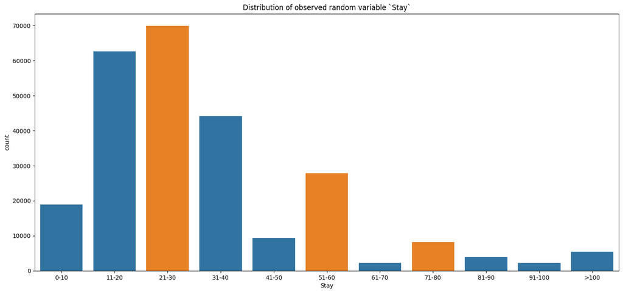

```python
target_name = "Stay"
palette = list(sns.color_palette(desat=.8))
ax = sns.countplot(x=target_name, data=train.sort_values(target_name))
plt.title("Distribution of observed random variable `Stay`")

[ax.containers[0][mode].set(facecolor=palette[1]) for mode in (2, 5, 7)];
```

There are three "modes" for variable `Stay` (orange bars). Maybe a sign of three different distributions.

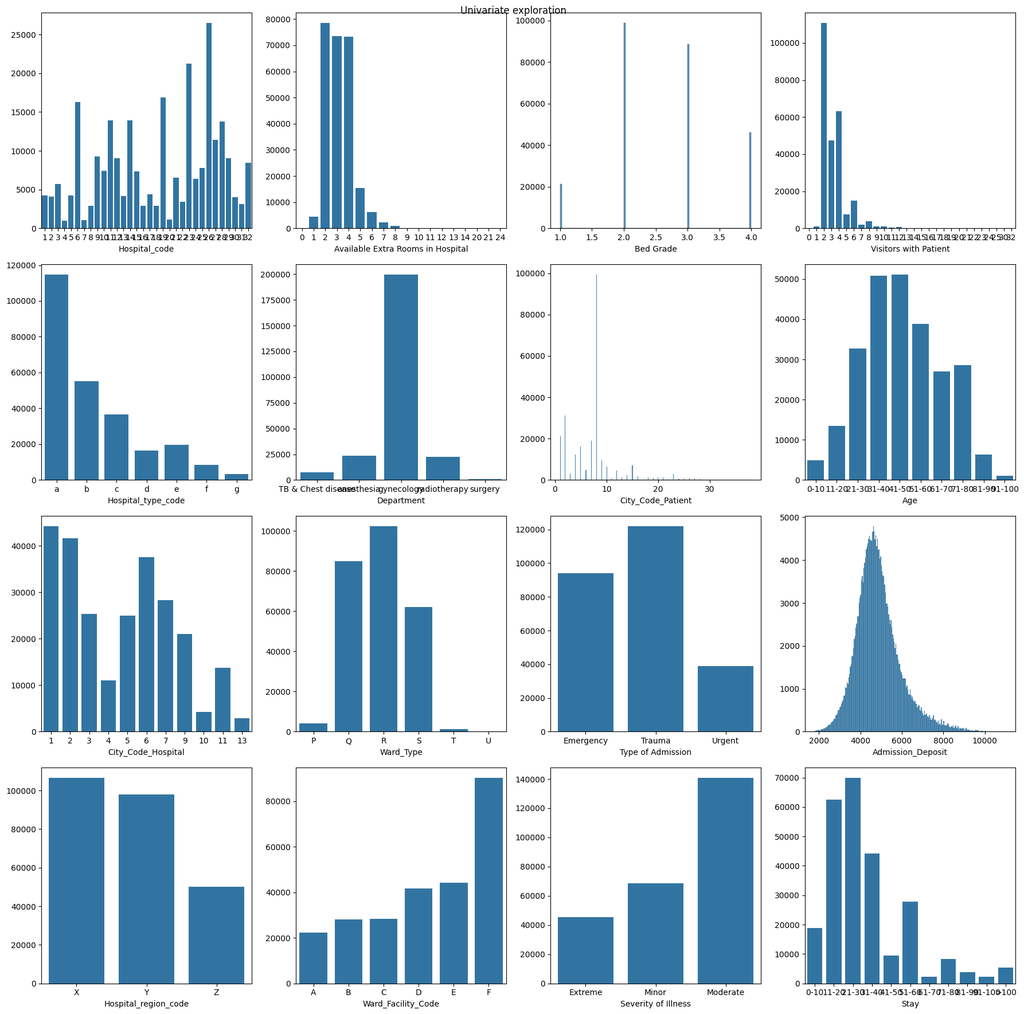

```python
fig, axs = plt.subplots(4, 4, figsize=(18,18))
for i, var_name in enumerate(train):
    ax = axs[i%4, i//4]
    plot = sns.histplot if train[var_name].dtype == float else sns.countplot
    plot(x=var_name, data=train.sort_values(var_name), ax=ax)
    ax.set_ylabel('')
plt.gcf().suptitle("Univariate exploration")
plt.tight_layout()
```

#### Observations:

There are many features, some might be useful and other not: we need to select only relevant ones. To do that, we can use the chi2 test of independance.

Other observations:

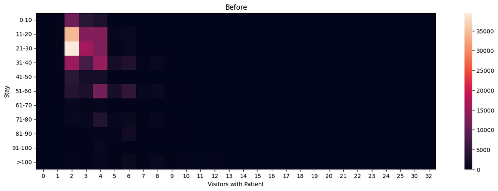

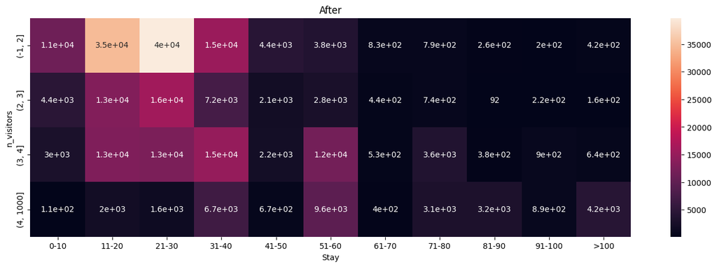

```python
varname = "Visitors with Patient"

plt.figure(figsize=(18,5))
ax = sns.heatmap(
    train[[varname, target_name]].assign(dummy=1).pivot_table(
        index=varname, columns=target_name, values="dummy", aggfunc="sum"
    ).fillna(0).T,
    square=True
)
ax.set_title("Before")

train["n_visitors"] = pd.cut(
    train[varname],
    pd.IntervalIndex.from_tuples([(-1, 2), (2, 3), (3, 4), (4, 1000)])
)
test["n_visitors"] = pd.cut(test[varname], train["n_visitors"].dtype.categories)

train, test = (df.drop([varname], axis=1) for df in (train, test))

plt.figure(figsize=(18,5))
ax = sns.heatmap(
    train[["n_visitors", target_name]].assign(dummy=1).pivot_table(
        index="n_visitors", columns=target_name, values="dummy", aggfunc="sum", observed=True
    ).fillna(0),
    square=True, annot=True
)
ax.set_title("After");
```

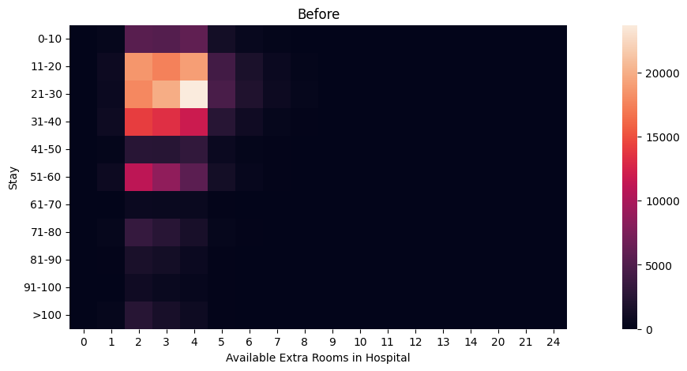

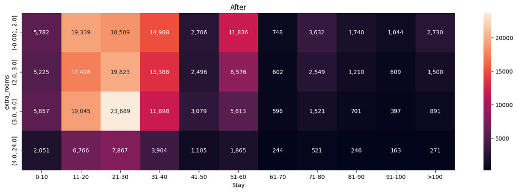

```python
varname = "Available Extra Rooms in Hospital"

plt.figure(figsize=(18,5))
ax = sns.heatmap(
    train[[varname, target_name]].assign(dummy=1).pivot_table(
        index=varname, columns=target_name, values="dummy", aggfunc="sum"
    ).fillna(0).T,
    square=True
)
ax.set_title("Before")

train["extra_rooms"] = pd.qcut(train[varname], 4)
test["extra_rooms"] = pd.cut(test[varname], train["extra_rooms"].dtype.categories)
train, test = (df.drop([varname], axis=1) for df in (train, test))

plt.figure(figsize=(18,5))
ax = sns.heatmap(
    train[["extra_rooms", target_name]].assign(dummy=1).pivot_table(
        index="extra_rooms", columns=target_name, values="dummy", aggfunc="sum", observed=True
    ).fillna(0),
    square=True, annot=True, fmt=",d"
)
ax.set_title("After");
```

### Multivariate analysis

Here, we plot the conditional distribution of the target variable w.r.t. supposedly dependent variables ($P(Y|X)$), and we compute the *Chi2 statistic to test if two variables are independent, and the **Spearman rank to test correlation.

*Pearson’s chi-squared test is a goodness-of-fit test for a multinomial distribution with given probabilities; that is, it assesses the null hypothesis that the observed frequencies (counts) are obtained by independent sampling of N observations from a categorical distribution with given expected frequencies.

**The Spearman rank-order correlation coefficient is a nonparametric measure of the monotonicity of the relationship between two datasets. Like other correlation coefficients, this one varies between -1 and +1 with 0 implying no correlation. The p-value roughly indicates the probability of an uncorrelated system producing datasets that have a Spearman correlation at least as extreme as the one computed from these datasets.

```python
def plot_conditional_distributions(y, x, data, layout=None, figsize=None, stat="probability"):
    # Plot the conditional probability of y given x (P(y|x)) for all values of x
    probability_table = (
        data[[x, y]]
        .assign(dummy=1)
        .pivot_table(index=y, columns=x, aggfunc="sum")
        .droplevel(0, 1)
        .apply(lambda x: x/x.sum())
    )

    plot = probability_table.plot.bar(
        subplots=True, sharey=True,
        layout=layout, figsize=figsize,
        width=1, edgecolor='k',
        ylabel=y, xlabel="",
        title=[""] * probability_table.shape[1]
    )
    [ax.tick_params(length=0) for ax in plot.flatten()]
    plt.tight_layout()
    return plot
```

```python
from scipy.stats import chi2_contingency
from itertools import combinations

def test_independence(y, x, data):
    observed = (
        data[[x, y]]
        .assign(dummy=1)
        .pivot_table(index=y, columns=x, aggfunc="sum")
        .droplevel(0, 1)
    )
#     return observed
    chi2, p, dof, expected = chi2_contingency(observed)

    expected = pd.DataFrame(expected, index=observed.index, columns=observed.columns)

    print(f"Chi-square Statistic: {chi2}")
    print(f"P-value: {p}")
    print(f"Degrees of Freedom: {dof}")
    print("Observed - Expected:")
    plt.figure()
    ax = sns.heatmap((1 - expected / observed).T, cbar=False, annot=True, square=True, cmap="vlag", vmin=-1, vmax=1)
    ax.tick_params(length=0)
    ax.set_title(rf"$\chi^2={chi2:,.2f} p={p:.0e}$")
    if p < .05:
        print(f'Reject H0: "{x}" and "{y}" are not independent')
    return chi2, p
```

Comparing Age and Stay, we observed that most patient where aged 31-50 and stayed for 21-30 days. Should the two variables be independent, the `1 - Expected/Observed` table (2nd graph below) should be zeros everywhere. As we can see, this is not the case and we observe more elderly patients remaining longer than what would be expected from independent distributions. We also see that younger patients tend to stay shorter than expected.

```
Chi-square Statistic: 2920.2824699733296
P-value: 0.0
Degrees of Freedom: 90
Observed - Expected:
Reject H0: "Age" and "Stay" are not independent
```

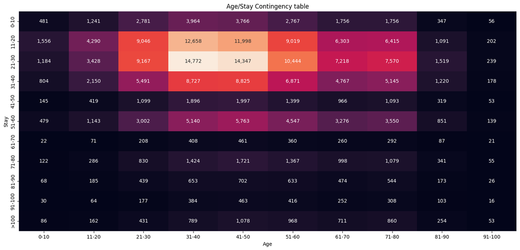

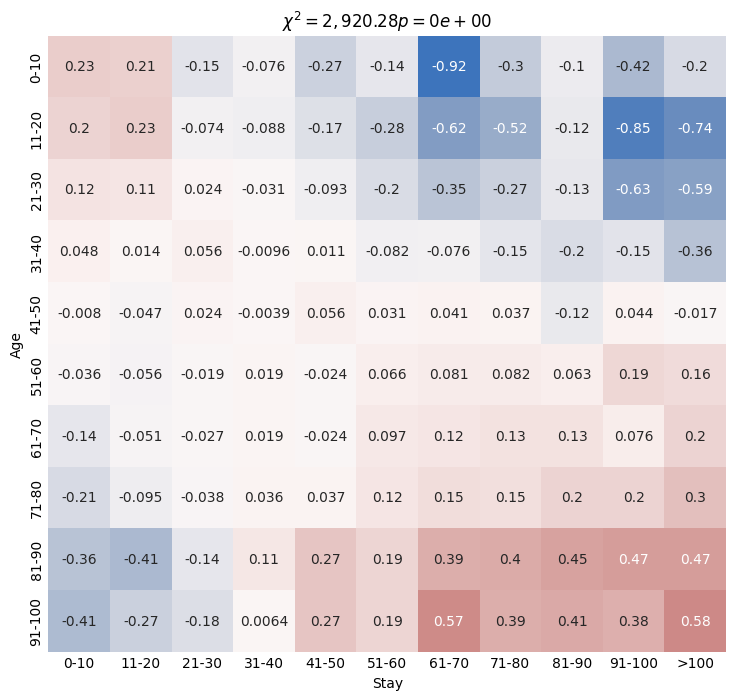

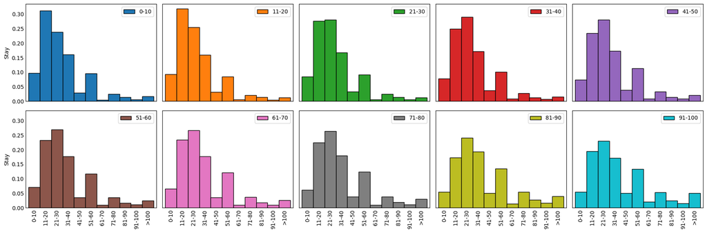

```python
sns.heatmap(
    train[["Age", "Stay"]].assign(dummy=1).pivot_table(index="Stay", columns="Age", aggfunc="sum").droplevel(0, 1),
    annot=True, fmt=",d", cbar=False
).set_title("Age/Stay Contingency table");

test_independence("Stay", "Age", train.dropna(axis=0, how="any"));
plot_conditional_distributions(target_name, "Age", train, (2, 5), (18, 6));
```

The $\chi^2$ test tells us whether two variables are independent, but more interestingly, it gives us a table of expected probabilities. We can use it to understand how one variable might be influenced by the other.

In the graphs below we see that we observed more people in surgery staying longer that would be expected from independent variables, and patients in the anesthesia department seem to have shorter stays than expected.

```
Chi-square Statistic: 1251.0813508519032
P-value: 2.444953736087778e-236
Degrees of Freedom: 40
Observed - Expected:
Reject H0: "Department" and "Stay" are not independent
```

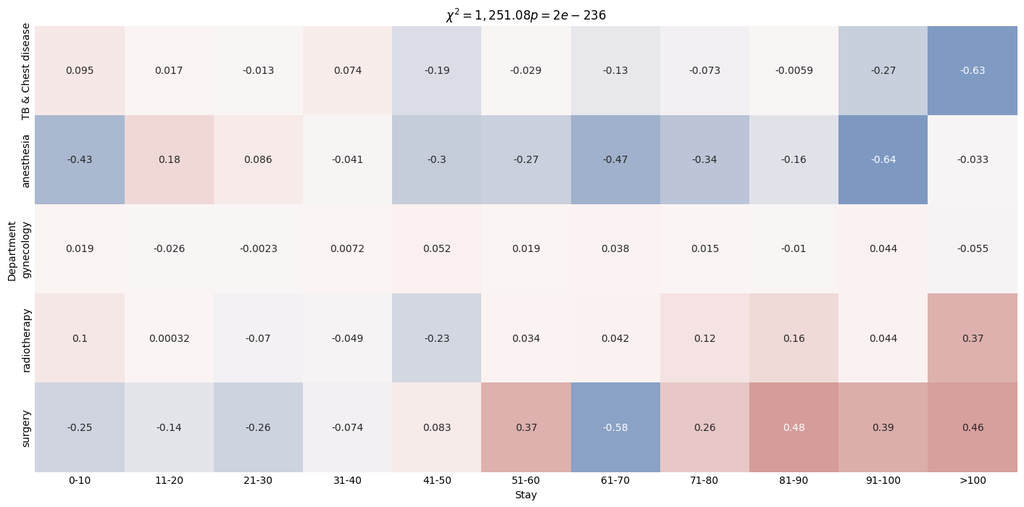

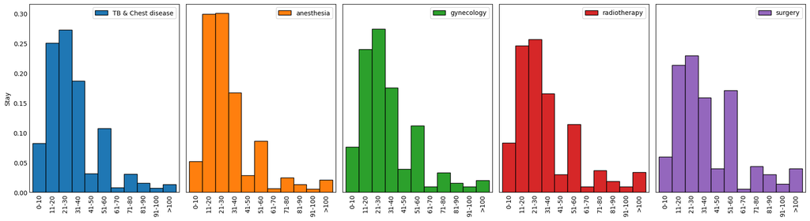

```python
test_independence("Stay", "Department", train.dropna(axis=0, how="any"));
plot_conditional_distributions(target_name, "Department", train, (1, 5), (18, 5));
```

When there are only 1 or 2 available rooms, the patient remains longer than the expected values. However, this might be a confounding variable, i.e. a variable that is explained by another.

```
Chi-square Statistic: 6313.260840085276
P-value: 0.0
Degrees of Freedom: 30
Observed - Expected:
Reject H0: "extra_rooms" and "Stay" are not independent
```

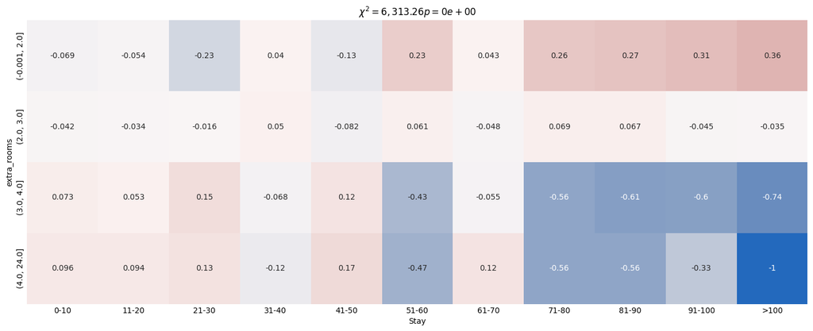

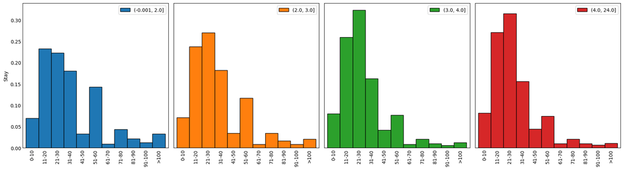

```python
test_independence("Stay", "extra_rooms", train.dropna(axis=0, how="any"));
plot_conditional_distributions(target_name, "extra_rooms", train, (1, 4), (18, 5));
```

`n_visitors` and `Severity of Illness` seem to be a good predictor for the target variable.

```
Chi-square Statistic: 91090.00076245035
P-value: 0.0
Degrees of Freedom: 30
Observed - Expected:
Reject H0: "n_visitors" and "Stay" are not independent
```

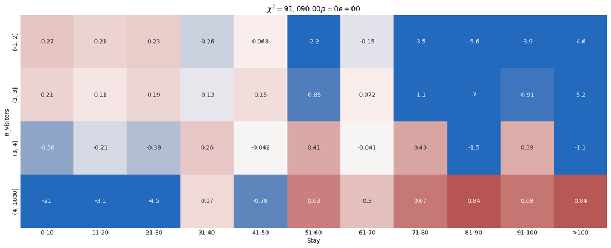

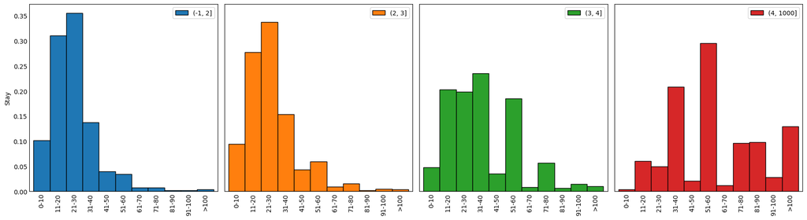

```python
test_independence("Stay", "n_visitors", train.dropna(axis=0, how="any"));
plot_conditional_distributions(target_name, "n_visitors", train, (1, 4), (18, 5));
```

```
Chi-square Statistic: 5207.100664457805
P-value: 0.0
Degrees of Freedom: 20
Observed - Expected:
Reject H0: "Severity of Illness" and "Stay" are not independent
```

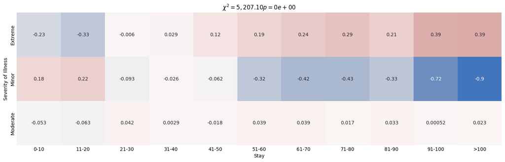

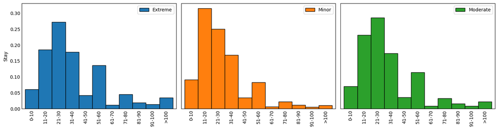

```python
test_independence(target_name, "Severity of Illness", train)
plot_conditional_distributions(target_name, "Severity of Illness", train, (1, 3), (15, 4));
```

`Severity of Illness` seems interesting as well, but it's ordinal and it does not sort in the right way. Let's fix this detail.

```python
train["Severity of Illness"] = train["Severity of Illness"].replace({"Extreme": 3, "Minor": 1, "Moderate": 2})
test["Severity of Illness"] = test["Severity of Illness"].replace({"Extreme": 3, "Minor": 1, "Moderate": 2})
```

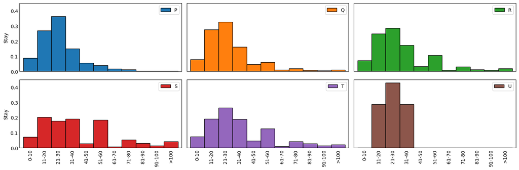

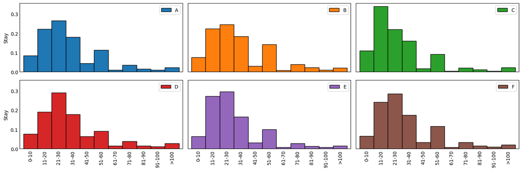

```python
plot_conditional_distributions(target_name, "Ward_Type", train, (2, 3), (15, 5));
plot_conditional_distributions(target_name, "Ward_Facility_Code", train, (2, 3), (15, 5));
```

```
Chi-square Statistic: 7771.40110434337
P-value: 0.0
Degrees of Freedom: 20
Observed - Expected:
Reject H0: "Type of Admission" and "Stay" are not independent
```

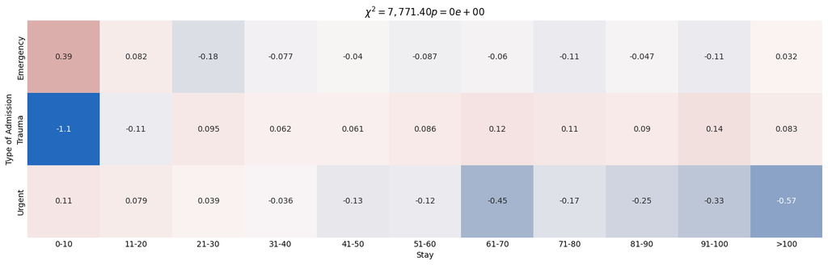

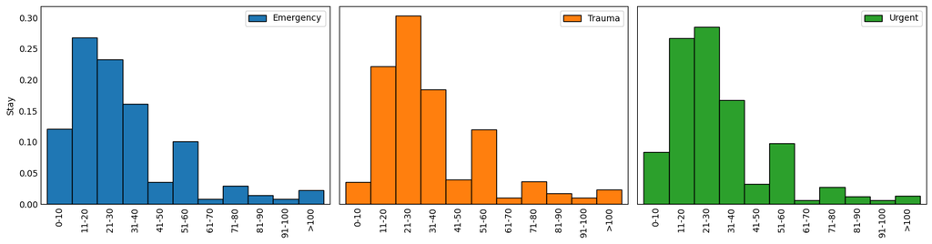

```python
test_independence(target_name, "Type of Admission", train)
plot_conditional_distributions(target_name, "Type of Admission", train, (1, 3), (15, 4));
```

We can also compute the Spearman Rank for all variables to test the correlation of the variables. Below, we see that we can eliminate `Bed Grade` and `City_Code_Patient`.

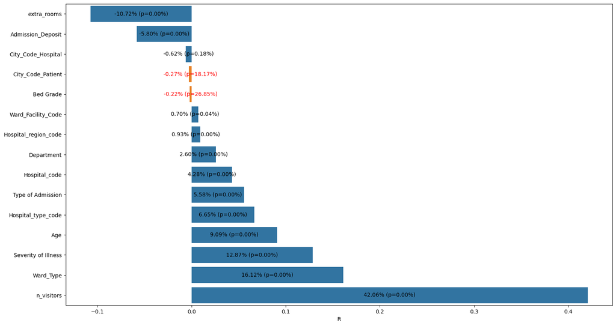

```python
from scipy.stats import spearmanr

def test_correlation(data, target_name, threshold=.05):
    columns = data.columns

    feats = [x for x in data.columns if x != target_name]

    R, p = (
        pd.DataFrame(x, index=columns, columns=columns)
        for x in spearmanr(data.dropna(how="any", axis=0))
    )

    df = pd.concat([df.loc[df.index != target_name, target_name] for df in (R, p)], axis=1)
    df.columns = ["R", "p"]
    df = df.sort_values("R")
    df["accept_H0"] = df["p"] < threshold
    plt.figure(figsize=(18, 10))
    ax = sns.barplot(df["R"], orient="h") #, annot=True, fmt=".3f", cbar=False, cmap="viridis")
    labels = list(map("{0[0]:.2%} (p={0[1]:.2%})".format, df.values))
    labels = ax.bar_label(ax.containers[0], labels, label_type="center", fontsize=10)
    for bar, label, accept in zip(ax.containers[0], labels, df["accept_H0"]):
        if not(accept):
            bar.set(facecolor=palette[1])
            label.set(color="red")
    return df

test_correlation(train.dropna(how="any", axis=0), target_name);
```

```python
to_drop = ["Bed Grade", "City_Code_Patient"]
train.drop(to_drop, axis=1, inplace=True)
test.drop(to_drop, axis=1, inplace=True)
```

### Machine Learning

Now I got a better understanding of the data and what transformation need to be done. First, we encode the data: one-hot encoding for categorical data, ordinal encoding for ordinal data and scale numerical data. The class below implement that. Then we encode the training and evaluation sets.

```python
from sklearn.preprocessing import OrdinalEncoder, OneHotEncoder, StandardScaler
from sklearn.exceptions import NotFittedError


class XYEncoder:
    """
    Helper class to encode a bunch of categorical and ordinal variables compatible with Scikit Learn
    categorical variables --> OneHot encoded
    ordinal variables --> Int encoded
    numerical variables --> Standard scaled
    """

    def __init__(self, categorical_variables:List[str], ordinal_variables:List[str], numerical_variables:List[str]):

        self.categorical_variables = categorical_variables
        self.ordinal_variables = ordinal_variables
        self.numerical_variables = numerical_variables

    def get_variable_groups(self):
        return self.categorical_variables, self.ordinal_variables, self.numerical_variables

    def get_encoders(self):
        self.assert_fitted()
        return self._categorical_encoder, self._ordinal_encoder, self._numerical_encoder

    def assert_fitted(self):
        if not hasattr(self, "encoders_"):
            raise NotFittedError()

    def fit(self, data:pd.DataFrame) -> pd.DataFrame:

        # Initialize the encoders
        # Ignoring the unknowns makes sure that all values are zeros for missing values
        self._categorical_encoder = OneHotEncoder(sparse_output=False, handle_unknown="ignore")
        self._ordinal_encoder = OrdinalEncoder()
        self._numerical_encoder = StandardScaler()
        self.encoders_ = [self._categorical_encoder, self._ordinal_encoder, self._numerical_encoder]

        # Fit the encoders
        for names, encoder in zip(self.get_variable_groups(), self.get_encoders()):
            encoder.fit(data[names])

        return self

    def transform(self, data:pd.DataFrame) -> pd.DataFrame:
        # Safety check
        self.assert_fitted()

        # Encode and store in a new dataframe
        encoded_data = []
        for names, encoder in zip(self.get_variable_groups(), self.get_encoders()):

            encoded_data.append(pd.DataFrame(
                encoder.transform(data[names]),
                columns=encoder.get_feature_names_out()
            ))

        return pd.concat(encoded_data, axis=1)

    def fit_transform(self, data: pd.DataFrame) -> pd.DataFrame:
        self.fit(data)
        return self.transform(data)
```

## Feature selection

During the exploration, we have seen that potentially many features should not be included in the model, and only some might actually have some chance of explaining the target variable.

Below, we select the features in multiple steps:

- We use what we learned from the exploration and from common sense to remove some columns
- We train a machine learning model with the resulting features
- We use the learned parameters to identify useless features and prune even more the feature set

```python
# Variables that are commented out will be excluded from the features
categorical_features = [
#     "Hospital_code",
#     "Hospital_type_code",
#     "City_Code_Hospital",
#     "Hospital_region_code",
    "Department",
    "Ward_Type",
    "Ward_Facility_Code",
    "Type of Admission",
]

ordinal_features = [
    "Severity of Illness",
    "Age",
    "Stay",
    "n_visitors",
    "extra_rooms"
]

numerical_features = [
    "Admission_Deposit"
]

xy_encoder = XYEncoder(categorical_features, ordinal_features, numerical_features)

train_encoded = xy_encoder.fit_transform(train)
test_encoded = xy_encoder.transform(test)

feature_names = [col for col in train_encoded.columns if col != target_name]
target_names = xy_encoder.encoders_[1].categories_[2]
X_train, y_train = train_encoded[feature_names], train_encoded[target_name]
X_test, y_test = test_encoded[feature_names], test_encoded[target_name]

print(X_train.shape)
```

```
(254750, 25)
```

#### Feature Selection

We remove some more columns once they have been extended.

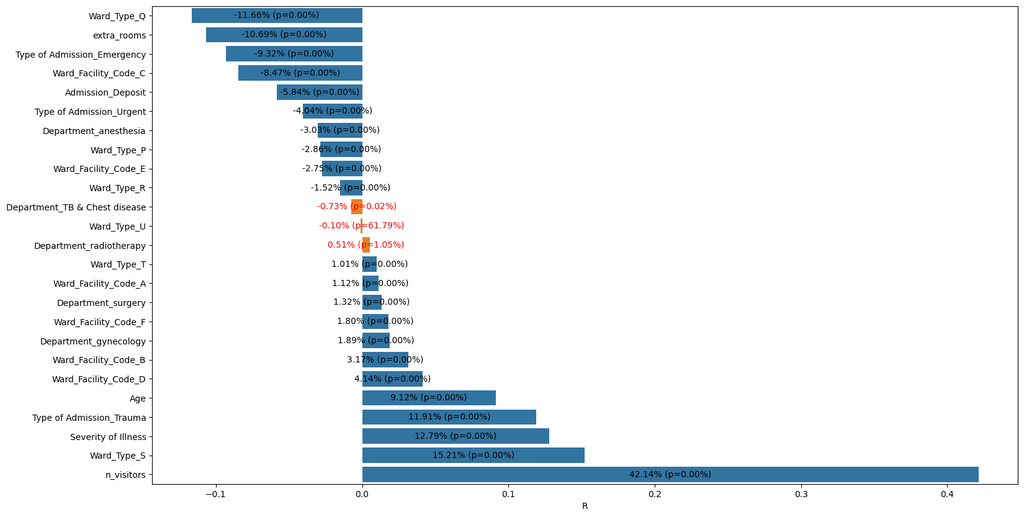

```python
feat_correlation = test_correlation(train_encoded, target_name, threshold=.00001)
to_drop = feat_correlation[~feat_correlation["accept_H0"]].index
X_train, X_test = (X.drop(to_drop, axis=1) for X in (X_train, X_test))
```

# Classification model with a decision tree

In the next cell, we use `GridSearchCV` to search the parameter space and find the best parameters for our predictive model.

```python
from sklearn.tree import DecisionTreeClassifier
from sklearn.pipeline import Pipeline
from sklearn.model_selection import GridSearchCV

search_space = {
    "tree__min_samples_split": [500, 1000, 2000, 3000],  # Min samples for splitting
    "tree__max_features": [10, 20, 25]  # Max features to consider for splitting
}

clf = Pipeline([
    ("tree", DecisionTreeClassifier())
])
# Select the optimal percentage of features with grid search
gs = GridSearchCV(clf, search_space, cv=3, scoring="f1_micro", n_jobs=-1)
gs.fit(X_train, y_train)  # set the best parameters
pd.DataFrame(gs.cv_results_)[
    [*map("param_{}".format, search_space), "mean_test_score", "std_test_score", "rank_test_score"]
].sort_values("rank_test_score").head(10)
```

|  | param_tree__min_samples_split | param_tree__max_features | mean_test_score | std_test_score | rank_test_score |
| --- | --- | --- | --- | --- | --- |
| 10 | 2000 | 25 | 0.39 | 0.00 | 1 |
| 9 | 1000 | 25 | 0.38 | 0.00 | 2 |
| 11 | 3000 | 25 | 0.38 | 0.00 | 3 |
| 5 | 1000 | 20 | 0.38 | 0.00 | 4 |
| 7 | 3000 | 20 | 0.38 | 0.00 | 5 |
| 6 | 2000 | 20 | 0.38 | 0.00 | 6 |
| 0 | 500 | 10 | 0.38 | 0.00 | 7 |
| 1 | 1000 | 10 | 0.38 | 0.00 | 8 |
| 4 | 500 | 20 | 0.38 | 0.00 | 9 |
| 2 | 2000 | 10 | 0.38 | 0.00 | 10 |

## Results

The decision tree only gives a performance of 39% accuracy on the evaluation set. Since the performance on the training set does not get higher except by making the model overfit, it is unlikely that we can get better results, although we can try with a random forest.

As we have observed during the exploration, the number of visitors is the feature with the most importance, followed by `Ward_Type_Q` and `Admission_Deposit`.

```python
from sklearn.tree import DecisionTreeClassifier
from sklearn.metrics import classification_report

clf = gs.estimator.set_params(**gs.best_params_).fit(X_train, y_train)

print(classification_report(y_train, clf.predict(X_train), zero_division=np.nan, target_names=target_names))
print(classification_report(y_test, clf.predict(X_test), zero_division=np.nan, target_names=target_names))
```

```
              precision    recall  f1-score   support

        0-10       0.35      0.13      0.19     18915
       11-20       0.40      0.40      0.40     62578
       21-30       0.40      0.69      0.50     69888
       31-40       0.39      0.19      0.26     44178
       41-50        nan      0.00      0.00      9386
       51-60       0.37      0.48      0.42     27890
       61-70        nan      0.00      0.00      2190
       71-80        nan      0.00      0.00      8223
       81-90       0.29      0.06      0.10      3897
      91-100        nan      0.00      0.00      2213
        >100       0.29      0.30      0.29      5392

    accuracy                           0.39    254750
   macro avg       0.36      0.20      0.20    254750
weighted avg       0.39      0.39      0.35    254750

              precision    recall  f1-score   support

        0-10       0.34      0.12      0.18      4689
       11-20       0.40      0.40      0.40     15561
       21-30       0.40      0.68      0.50     17603
       31-40       0.39      0.19      0.26     10981
       41-50        nan      0.00      0.00      2357
       51-60       0.38      0.48      0.42      7128
       61-70        nan      0.00      0.00       554
       71-80        nan      0.00      0.00      2031
       81-90       0.22      0.05      0.08       941
      91-100        nan      0.00      0.00       552
        >100       0.26      0.26      0.26      1291

    accuracy                           0.39     63688
   macro avg       0.34      0.20      0.19     63688
weighted avg       0.38      0.39      0.35     63688
```

```python
feature_importances = pd.Series(
    clf[-1].feature_importances_,
    index=X_test.columns,
    name="feature importance"
)

feature_importances.sort_values(ascending=False).to_frame()
```

|  | feature importance |
| --- | --- |
| n_visitors | 0.50 |
| Ward_Type_Q | 0.17 |
| Admission_Deposit | 0.06 |
| Severity of Illness | 0.05 |
| Ward_Type_S | 0.04 |
| Type of Admission_Emergency | 0.04 |
| Ward_Type_P | 0.04 |
| Ward_Facility_Code_C | 0.03 |
| Ward_Facility_Code_D | 0.02 |
| Type of Admission_Trauma | 0.01 |
| extra_rooms | 0.01 |
| Age | 0.01 |
| Department_anesthesia | 0.01 |
| Ward_Facility_Code_E | 0.00 |
| Type of Admission_Urgent | 0.00 |
| Department_gynecology | 0.00 |
| Ward_Type_R | 0.00 |
| Ward_Facility_Code_A | 0.00 |
| Ward_Facility_Code_B | 0.00 |
| Ward_Facility_Code_F | 0.00 |
| Department_surgery | 0.00 |
| Ward_Type_T | 0.00 |

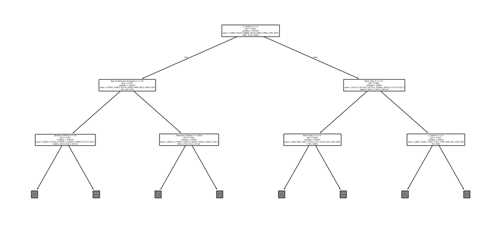

```python
import pickle
from sklearn.tree import plot_tree

plot_tree(clf[0], feature_names=X_train.columns, max_depth=2)
plt.savefig("decision_tree.png", dpi=300)
```